# DEGs

Tomato TET3 RNA-seq

Javier Antúnez Sánchez

July 2025

### Transgene expression

Before computing Differentially expressed genes let’s have a look at the expression of the transgenes in the T-DNA, in our case the human TET3 catalytic domain and the Kanamycin resistance gene.

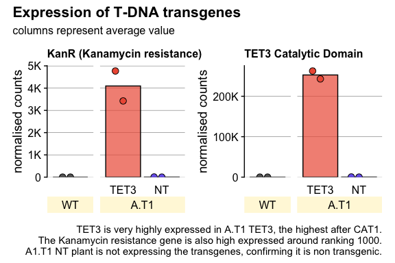

| id | WT_1 | WT_2 | A4_1 | A4_2 | A17_1 | A17_2 |
| --- | --- | --- | --- | --- | --- | --- |
| gene:TET3c | 0.000 | 4.021596e+00 | 242908.618 | 262530.337 | 367.0443 | 51.51222 |
| gene:Solyc12g094620.3 | 241158.320 | 2.420327e+05 | 247572.633 | 205269.003 | 202258.8041 | 212001.40416 |
| gene:Solyc03g034220.3 | 65747.586 | 7.931491e+04 | 80737.203 | 93134.705 | 192188.1051 | 162821.54279 |
| gene:Solyc09g091660.3 | 64107.233 | 5.750781e+04 | 85233.347 | 91258.756 | 59999.9158 | 63134.90341 |
| gene:Solyc07g062700.3 | 51378.229 | 4.075183e+04 | 46074.651 | 91083.069 | 42760.0337 | 51224.13337 |
| gene:Solyc08g082190.3 | 81507.989 | 6.747936e+04 | 58266.537 | 84985.748 | 42090.6445 | 36319.93098 |
| gene:Solyc09g010800.5.1 | 105202.094 | 1.195962e+05 | 66081.411 | 79034.832 | 123435.1170 | 109602.74178 |
| gene:Solyc09g010630.3 | 61421.114 | 5.175492e+04 | 63929.265 | 76631.822 | 48570.5309 | 57206.22843 |
| gene:Solyc08g065610.3 | 71407.740 | 3.125383e+04 | 87431.136 | 75521.089 | 8362.3879 | 6723.29867 |
| gene:Solyc03g122340.3 | 57168.552 | 3.932819e+04 | 37965.036 | 70366.622 | 36012.6405 | 34680.12531 |

[output cut: 990 more lines]

### DEGs

Get the statistics for each of the comparisons in a list

get the counts for the DEGs (also as a list)

get the variance stabilized counts for the DEGs (also as a list)

Join all DEGs with its counts in a unique table

And you can filter it as a tibble

| comparison | id | baseMean | log2FoldChange | lfcSE | stat | pvalue | padj | WT_1 | WT_2 | A4_1 | A4_2 | A17_1 | A17_2 |
| --- | --- | --- | --- | --- | --- | --- | --- | --- | --- | --- | --- | --- | --- |
| A4_vs_WT | gene:Solyc02g071010.1 | 7355.87 | -2.147401 | 0.2821906 | -7.609751 | 2.746238e-14 | 1.221310e-11 | 9.509956 | 9.648702 | 8.456659 | 8.317984 | 14.7262 | 13.99457 |
| A17_vs_WT | gene:Solyc02g071010.1 | 7355.87 | 5.380881 | 0.2680747 | 20.072321 | 1.288435e-89 | 2.584858e-85 | 9.509956 | 9.648702 | 8.456659 | 8.317984 | 14.7262 | 13.99457 |
| A17_vs_A4 | gene:Solyc02g071010.1 | 7355.87 | 7.528282 | 0.2784825 | 27.033229 | 6.014976e-161 | 1.263265e-156 | 9.509956 | 9.648702 | 8.456659 | 8.317984 | 14.7262 | 13.99457 |

Alternative you can filter and keep the list structure

Write the DEGs to a Excel file with tabs for each comparison

And save it as a RDS object for easy loading

### DEGs number

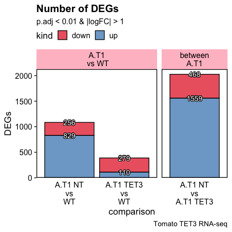

### Volcano plots

Using enhanced volcano

#### Zoom out

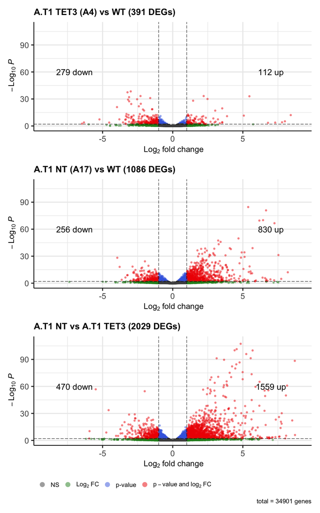

#### Zoom in

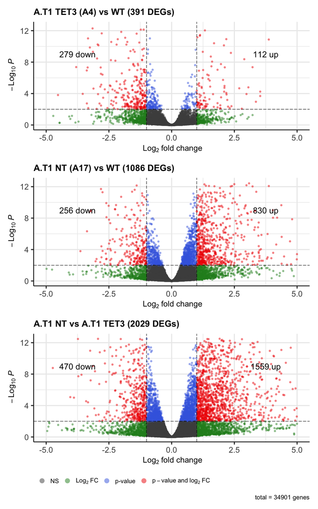

#### Zoom in for figure

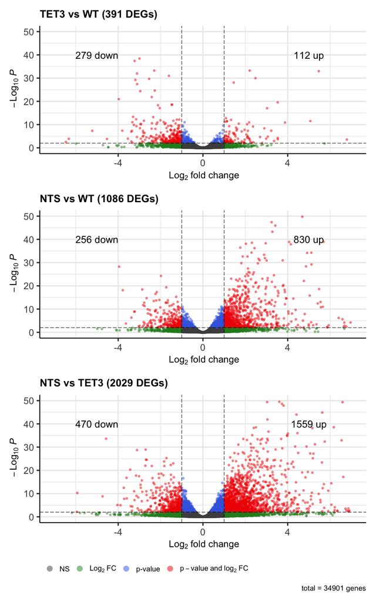

A4

### Go term analysis

Done in a different Rmd file